# week 6: integers and other monsters

ordered categories

## Ordered categorical outcomes

Ordered categories are variables that are discrete, like a count, except that the values merely indicate different ordered levels.<sup>1</sup> Most Likert scale questions are ordered categories, even though we pretend they’re continuous (see polychoric correlations).

If we want to model an outcome as an ordered categorical variable, what we’re really asking is how does moving along an associated predictor variable move predictions in the outcome progressively through the categories *in sequence*. We must therefore model our outcomes in the right order.

To do so, we’ll use the principles of the generalized linear model discussed last week. That is, we use a link function – the **CUMULATIVE LINK FUNCTION** – to model the probability of a value that is that value or smaller.

[^1]: Actual counts communicate meaningful and consistent distance between possible values.

### example: the trolley problem

```r
data(Trolley, package = "rethinking")
trolley <- Trolley
head(trolley)
```

```
   case response order     id age male           edu action intention contact
1 cfaqu        4     2 96;434  14    0 Middle School      0         0       1
2 cfbur        3    31 96;434  14    0 Middle School      0         0       1
3 cfrub        4    16 96;434  14    0 Middle School      0         0       1
4 cibox        3    32 96;434  14    0 Middle School      0         1       1
5 cibur        3     4 96;434  14    0 Middle School      0         1       1
6 cispe        3     9 96;434  14    0 Middle School      0         1       1
  story action2
1   aqu       1
2   bur       1
3   rub       1
4   box       1
5   bur       1
6   spe       1
```

```r
trolley %>%
  ggplot(aes( x=response )) +
  geom_histogram()
```

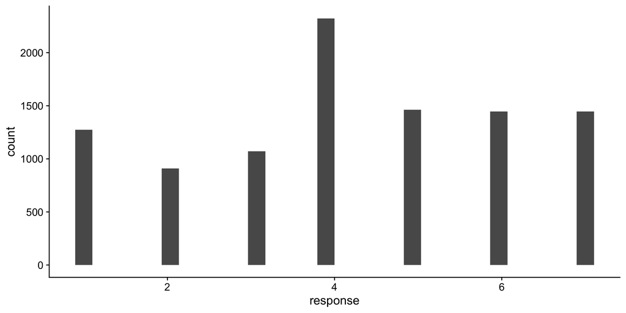

```r
trolley %>%
  count(response) %>%
  mutate(pr_k     = n/nrow(trolley),
         cum_pr_k = cumsum(pr_k)) %>%
  ggplot(aes(x = response, y = cum_pr_k)) +
  geom_point(size = 3, color = "#1c5253") +
  geom_line(color = "#1c5253", alpha = .3) +
  labs(x = "response",
       y = "cumulative probability")
```

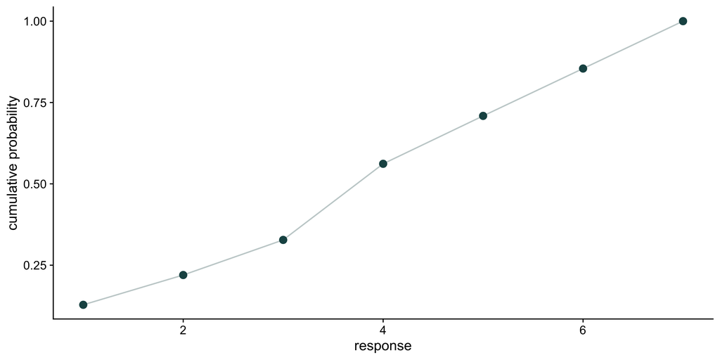

```r
# primary data
trolley_plot <-
  trolley %>%
  count(response) %>%
  mutate(pr_k     = n / nrow(trolley),
         cum_pr_k = cumsum(n / nrow(trolley))) %>%
  mutate(discrete_probability = ifelse(response == 1, cum_pr_k, cum_pr_k - pr_k))

# annotation
text <-
  tibble(text     = 1:7,
         response = seq(from = 1.25, to = 7.25, by = 1),
         cum_pr_k = trolley_plot$cum_pr_k - .065)

trolley_plot %>%
  ggplot(aes(x = response, y = cum_pr_k,
             color = cum_pr_k, fill = cum_pr_k)) +
  geom_line() +
  geom_point(shape = 21, colour = "grey92",
             size = 2.5, stroke = 1) +
  geom_linerange(aes(ymin = 0, ymax = cum_pr_k),
                 alpha = 1/2) +
  geom_linerange(aes(x = response + .025,
                     ymin = ifelse(response == 1, 0, discrete_probability),
                     ymax = cum_pr_k),
                 color = "black") +
  # number annotation
  geom_text(data = text,
            aes(label = text),
            size = 4) +
  scale_x_continuous(breaks = 1:7) +
  scale_y_continuous("cumulative proportion", breaks = c(0, .5, 1),
                     limits = c(0, 1.1)) +
  theme(axis.ticks = element_blank(),
        axis.title.y = element_text(angle = 90),
        legend.position = "none")
```

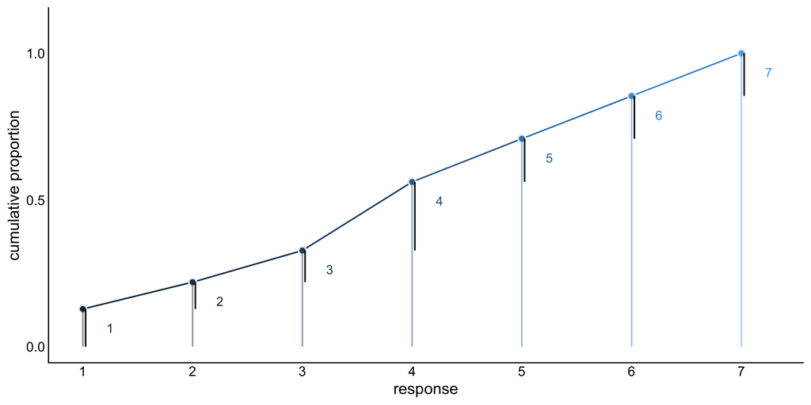

On to the modeling. We’ll start with an intercept-only model.

$$\begin{align*}
R_i &\sim \text{Categorical}(p) \\
\text{logit}(p_k) = \alpha_k - \phi \\
\phi &= 0 \\
\alpha_k &\sim \text{Normal}(0, 1.5)
\end{align*}$$

Remember, $\phi$ doesn’t have an intercept because there’s a $\alpha$ for each cut point.

```r
m1 <- brm(
  data = trolley,
  family = cumulative,
  response ~ 1,
  prior = c( prior(normal(0, 1.5), class = Intercept) ),
  iter=2000, warmup=1000, cores=4, chains=4,
  file=here("files/models/62.1")
)
```

[output not shown]

[output cut: 43 more lines]

[output not shown]

```r
summary(m1)
```

```
 Family: cumulative
  Links: mu = logit
Formula: response ~ 1
   Data: trolley (Number of observations: 9930)
  Draws: 4 chains, each with iter = 2000; warmup = 1000; thin = 1;
         total post-warmup draws = 4000

Regression Coefficients:
             Estimate Est.Error l-95% CI u-95% CI Rhat Bulk_ESS Tail_ESS
Intercept[1]    -1.92      0.03    -1.97    -1.86 1.00     2592     2822
Intercept[2]    -1.27      0.02    -1.31    -1.22 1.00     3537     3283
Intercept[3]    -0.72      0.02    -0.76    -0.68 1.00     4001     3294
Intercept[4]     0.25      0.02     0.21     0.29 1.00     4255     3334
Intercept[5]     0.89      0.02     0.85     0.93 1.00     4282     3526
Intercept[6]     1.77      0.03     1.71     1.83 1.00     4827     3504

Further Distributional Parameters:
     Estimate Est.Error l-95% CI u-95% CI Rhat Bulk_ESS Tail_ESS
disc     1.00      0.00     1.00     1.00   NA       NA       NA

Draws were sampled using sample(hmc). For each parameter, Bulk_ESS
and Tail_ESS are effective sample size measures, and Rhat is the potential
scale reduction factor on split chains (at convergence, Rhat = 1).
```

The thresholds are in the logit-metric. Let’s convert these back to probabilities.

```r
gather_draws(m1, `b_.*`, regex=T) %>%
  mutate(.value = inv_logit_scaled(.value)) %>%
  mean_qi
```

```
# A tibble: 6 × 7
  .variable      .value .lower .upper .width .point .interval
  <chr>           <dbl>  <dbl>  <dbl>  <dbl> <chr>  <chr>
1 b_Intercept[1]  0.128  0.122  0.135   0.95 mean   qi
2 b_Intercept[2]  0.220  0.212  0.228   0.95 mean   qi
3 b_Intercept[3]  0.328  0.319  0.337   0.95 mean   qi
4 b_Intercept[4]  0.562  0.552  0.571   0.95 mean   qi
5 b_Intercept[5]  0.709  0.700  0.717   0.95 mean   qi
6 b_Intercept[6]  0.854  0.847  0.861   0.95 mean   qi
```

### exercise

Create a plot showing the posterior predictive distribution for the intercept-only model (m1). Can you visualize both the posterior and the observed data?

### solution

```r
predicted_draws(m1, newdata = data.frame(1)) %>%
  count(.prediction) %>%
  mutate(pr_k = n / sum(n)) %>%
  ggplot(aes(x = .prediction, y = pr_k)) +
  geom_col(fill = "#1c5253", alpha = 0.7) +
  geom_point(data = trolley_plot, aes(x = response),
             color = "#3d405b", size = 2) +
  labs(x = "response",
       y = "probability",
       title = "Posterior Predictive Distribution")
```

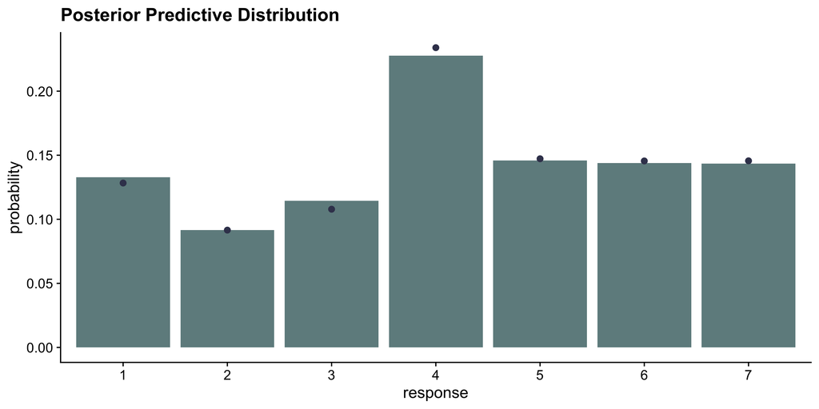

### adding predictors

Now let’s add the features of the story – contact, action, and intention – as predictors in our model. Let’s expand our mathematical model. Here’s our original:

$$\begin{align*}
R_i &\sim \text{Categorical}(p) \\
\text{logit}(p_k) = \alpha_k - \phi_i \\
\phi_i &= 0 \\
\alpha_k &\sim \text{Normal}(0, 1.5)
\end{align*}$$

McElreath proposes the following causal formula:

$$\phi_i = \beta_1\text{action}_i + \beta_2\text{contact}_i + \beta_3\text{intention}_i$$

```r
m2 <- brm(
  data = trolley,
  family = cumulative,
  response ~ 1 + action + contact + intention,
  prior = c( prior(normal(0, 1.5), class = Intercept),
             prior(normal(0, 0.5), class = b)),
  iter=2000, warmup=1000, cores=4, chains=4,
  file=here("files/models/62.2")
)
```

[output not shown]

[output cut: 43 more lines]

[output not shown]

```r
m2
```

```
 Family: cumulative
  Links: mu = logit
Formula: response ~ 1 + action + contact + intention
   Data: trolley (Number of observations: 9930)
  Draws: 4 chains, each with iter = 2000; warmup = 1000; thin = 1;
         total post-warmup draws = 4000

Regression Coefficients:
             Estimate Est.Error l-95% CI u-95% CI Rhat Bulk_ESS Tail_ESS
Intercept[1]    -2.83      0.05    -2.92    -2.73 1.00     2971     2892
Intercept[2]    -2.14      0.04    -2.23    -2.06 1.00     3288     2947
Intercept[3]    -1.56      0.04    -1.64    -1.49 1.00     3421     2769
Intercept[4]    -0.54      0.04    -0.62    -0.47 1.00     3635     3302
Intercept[5]     0.13      0.04     0.05     0.20 1.00     3749     3271
Intercept[6]     1.03      0.04     0.95     1.11 1.00     4273     3462
action          -0.70      0.04    -0.78    -0.62 1.00     3717     3025
contact         -0.95      0.05    -1.05    -0.85 1.00     3709     3149
intention       -0.71      0.04    -0.79    -0.64 1.00     5278     3236

Further Distributional Parameters:
     Estimate Est.Error l-95% CI u-95% CI Rhat Bulk_ESS Tail_ESS
disc     1.00      0.00     1.00     1.00   NA       NA       NA

Draws were sampled using sample(hmc). For each parameter, Bulk_ESS
and Tail_ESS are effective sample size measures, and Rhat is the potential
scale reduction factor on split chains (at convergence, Rhat = 1).
```

```r
gather_draws(m2, `b_.*`, regex=T) %>%
  filter(!str_detect(.variable, "[0-9]")) %>%
  mutate(.variable = str_remove(.variable, "b_")) %>%
  ggplot( aes(x = .value, y = .variable) ) +
  geom_vline( aes(xintercept = 0), linetype = "dashed", alpha = .3 ) +
  stat_dist_halfeye(fill = "#5e8485") +
  scale_x_continuous("marginal posterior", breaks = -5:0 / 4) +
  scale_y_discrete(NULL)
```

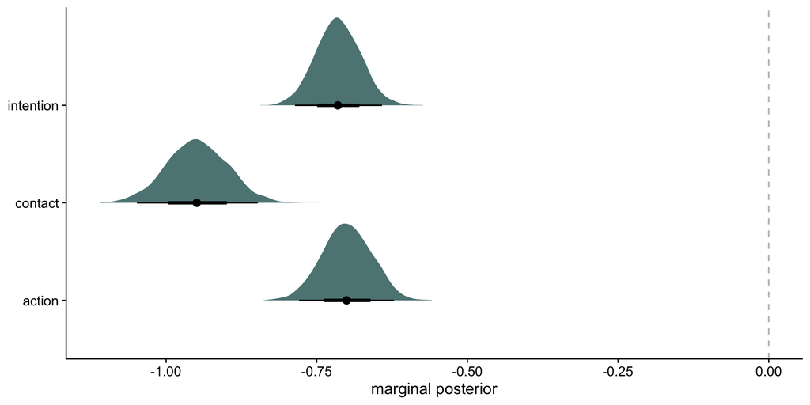

```r
nd <-
  trolley %>%
  distinct(action, contact, intention) %>%
  mutate(combination = str_c(action, contact, intention, sep = "_"))

f <- predicted_draws( m2 , newdata = nd )

f
```

```
# A tibble: 24,000 × 9
# Groups:   action, contact, intention, combination, .row [6]
   action contact intention combination  .row .chain .iteration .draw
    <int>   <int>     <int> <chr>       <int>  <int>      <int> <int>
 1      0       1         0 0_1_0           1     NA         NA     1
 2      0       1         0 0_1_0           1     NA         NA     2
 3      0       1         0 0_1_0           1     NA         NA     3
 4      0       1         0 0_1_0           1     NA         NA     4
 5      0       1         0 0_1_0           1     NA         NA     5
 6      0       1         0 0_1_0           1     NA         NA     6
 7      0       1         0 0_1_0           1     NA         NA     7
 8      0       1         0 0_1_0           1     NA         NA     8
 9      0       1         0 0_1_0           1     NA         NA     9
10      0       1         0 0_1_0           1     NA         NA    10
# ℹ 23,990 more rows
# ℹ 1 more variable: .prediction <fct>
```

```r
f %>%
  as.data.frame() %>%
  mutate(
    across( c(action, contact, intention) ,
            as.character),
    action  = str_c("action = ",  action),
    contact = str_c("contact = ", contact)) %>%
  count(action, contact, intention, .prediction) %>%
  ggplot( aes(x=.prediction, y=n, color=intention) )+
  geom_point() +
  geom_line(aes(group=intention)) +
  facet_grid(~action+contact) +
  labs( x="response",
        y="count" )
```

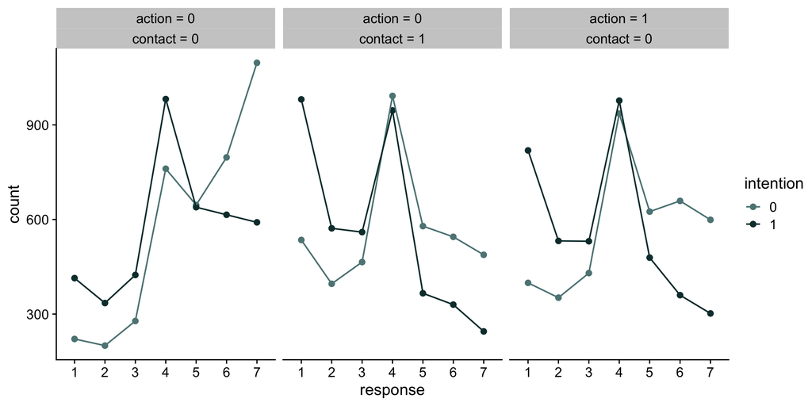

### exercise

Create a new model that models the interaction between intention and the other variables. Then:

1. Compare the fits of these models using PSIS or WAIC.
2. Plot the posterior predictive distribution. How does it differ from our previous model?

### solution

```r
m2_complex <- brm(
  data = trolley,
  family = cumulative,
  response ~ 1 + action + contact + intention +
    action:intention + contact:intention,
  prior = c(prior(normal(0, 1.5), class = Intercept),
            prior(normal(0, 0.5), class = b)),
  iter = 2000, warmup = 1000, cores = 4, chains = 4,
  file=here("files/models/62.2com")
)
```

[output not shown]

[output cut: 43 more lines]

[output not shown]

### solution: compare

```r
m2  <-       add_criterion(m2,        "loo")
m2_complex <- add_criterion(m2_complex, "loo")

loo_compare(m2, m2_complex, criterion = "loo") %>%
  print(simplify = F)
```

```
      model elpd_diff se_diff p_worse diag_diff diag_elpd elpd_loo se_elpd_loo
 m2_complex       0.0     0.0      NA                     -18464.7        40.4
         m2     -80.4    12.5    1.00                     -18545.0        37.9
 p_loo se_p_loo   looic se_looic
  11.0      0.1 36929.3     80.8
   9.0      0.0 37090.1     75.8
```

```r
m2  <-       add_criterion(m2,        "waic")
m2_complex <- add_criterion(m2_complex, "waic")

loo_compare(m2, m2_complex, criterion = "waic") %>%
  print(simplify = F)
```

```
      model elpd_diff se_diff p_worse diag_diff diag_elpd elpd_waic
 m2_complex       0.0     0.0      NA                      -18464.7
         m2     -80.4    12.5    1.00                      -18545.0
 se_elpd_waic p_waic se_p_waic    waic se_waic
         40.4   11.0       0.1 36929.3    80.8
         37.9    9.0       0.0 37090.0    75.8
```

### solution: ppd

```r
predicted_draws(object = m2_complex, newdata = nd) %>%
  mutate(
    intention=as.character(intention),
    action  = str_c("action = ",  action),
    contact = str_c("contact = ", contact)) %>%
  count(action, contact, intention, .prediction) %>%
  ggplot( aes(x=.prediction, y=n, color=intention) )+
  geom_point() +
  geom_line(aes(group=intention)) +
  facet_grid(~action+contact) +
  labs( x="response",
        y="count" )
```

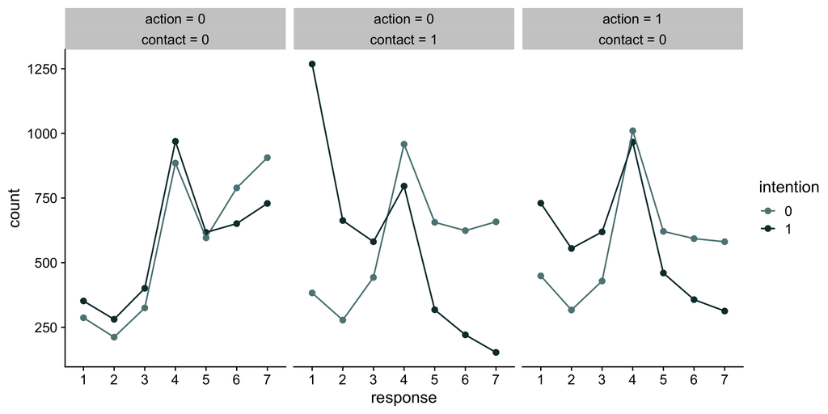

### solution: ppd

```r
p1 = predicted_draws(object = m2, newdata = nd) %>%
  mutate(model = "simple")
p2 = predicted_draws(object = m2_complex, newdata = nd) %>%
  mutate(model = "complex")

p1 %>% full_join(p2) %>%
  mutate(
    intention=as.character(intention),
    action  = str_c("action = ",  action),
    contact = str_c("contact = ", contact)) %>%
  count(model, action, contact, intention, .prediction) %>%
  ggplot( aes(x=.prediction, y=n,
              color=interaction(intention,model,
                                sep="-",lex.order=TRUE)) )+
  geom_point() +
  geom_line(aes(group=interaction(intention,model,sep="-",lex.order=TRUE))) +
  facet_grid(~action+contact) +
  labs( x="response",
        y="count",
        color = "intention+model")
```

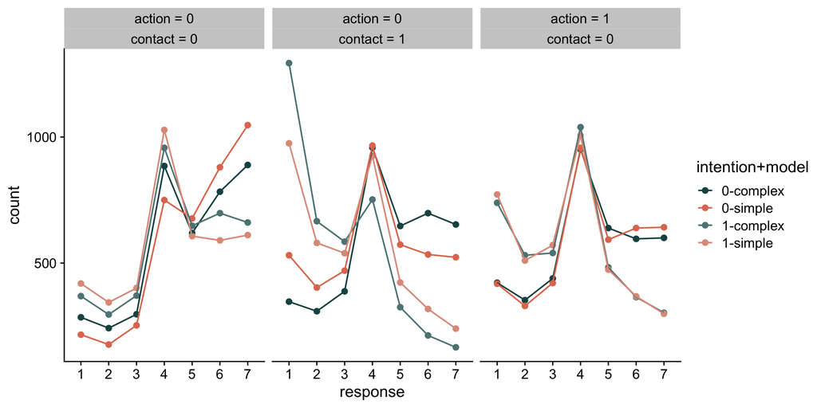

## Ordered categorical predictors

```r
distinct(trolley, edu)
```

```
                   edu
1        Middle School
2    Bachelor's Degree
3         Some College
4      Master's Degree
5 High School Graduate
6      Graduate Degree
7     Some High School
8    Elementary School
```

```r
trolley <-
  trolley %>%
  mutate(edu_new =
           recode(edu,
                  "Elementary School" = 1,
                  "Middle School" = 2,
                  "Some High School" = 3,
                  "High School Graduate" = 4,
                  "Some College" = 5,
                  "Bachelor's Degree" = 6,
                  "Master's Degree" = 7,
                  "Graduate Degree" = 8) %>%
           as.integer())
```

To incorporate this variable as a **MONOTONIC CATEOGORICAL PREDICTOR**, we’ll set up a notation such that each step up in value comes with its own incremental or marginal effect on the outcome.

$$\phi_i = \sum_{j=1}^7 \delta_j$$
We only need 7 because the first category is absorbed into the intercept for $\phi$. So our full formula for this parameter is:
$$\phi_i = \beta_1\text{action}_i + \beta_2\text{contact}_i + \beta_3\text{intention}_i + \beta_E\sum_{j=0}^{E_i-1} \delta_j$$
where $\beta_E$ is the average effect

$$\begin{align*}
\text{response}_i &\sim \text{Categorical}(\mathbf{p}) \\
\text{logit}(p_k) &= \alpha_k - \phi_i \\
\phi_i &= \beta_1\text{action}_i + \beta_2\text{contact}_i + \beta_3\text{intention}_i + \beta_4 \text{ mo(edu_new}_i, \boldsymbol{\delta}) \\
\alpha_k &\sim \text{Normal}(0, 1.5) \\
\beta_1, \ldots, \beta_3 &\sim \text{Normal}(0, 1) \\
\beta_4 &\sim \text{Normal}(0, 0.143) \\
\boldsymbol{\delta} &\sim \text{Dirichlet}(2, 2, 2, 2, 2, 2, 2),
\end{align*}$$

```r
m3 <-
  brm(data = trolley,
      family = cumulative,
      response ~ 1 + action + contact + intention + mo(edu_new),  # note the `mo()` syntax
      prior = c(prior(normal(0, 1.5), class = Intercept),
                prior(normal(0, 1), class = b),
                # note the new kinds of prior statements
                prior(normal(0, 0.143), class = b, coef = moedu_new),
                prior(dirichlet(2, 2, 2, 2, 2, 2, 2), class = simo, coef = moedu_new1)),
      iter = 2000, warmup = 1000, cores = 4, chains = 4,
      seed = 12,
      file = here("files/models/62.3"))
```

[output not shown]

[output cut: 43 more lines]

[output not shown]

*Warning: this will probably take 20 minutes or so to run on your laptop.* [You can download my model file here.](https://raw.githubusercontent.com/sjweston/uobayes/9762401fc0f67cc642610fd59d45c8bee185f176/files/share/62.3.rds)

```r
m3
```

```
 Family: cumulative
  Links: mu = logit
Formula: response ~ 1 + action + contact + intention + mo(edu_new)
   Data: trolley (Number of observations: 9930)
  Draws: 4 chains, each with iter = 2000; warmup = 1000; thin = 1;
         total post-warmup draws = 4000

Regression Coefficients:
             Estimate Est.Error l-95% CI u-95% CI Rhat Bulk_ESS Tail_ESS
Intercept[1]    -3.13      0.17    -3.51    -2.85 1.00     1637     1657
Intercept[2]    -2.45      0.16    -2.82    -2.17 1.00     1650     1580
Intercept[3]    -1.87      0.16    -2.24    -1.59 1.00     1624     1651
Intercept[4]    -0.84      0.16    -1.21    -0.57 1.00     1620     1544
Intercept[5]    -0.18      0.16    -0.54     0.09 1.00     1590     1631
Intercept[6]     0.73      0.16     0.36     1.01 1.00     1590     1604
action          -0.71      0.04    -0.78    -0.62 1.00     3761     2731
contact         -0.96      0.05    -1.06    -0.86 1.00     3569     3042
intention       -0.72      0.04    -0.79    -0.65 1.00     4138     2727
moedu_new       -0.05      0.03    -0.11    -0.01 1.00     1581     1482

Monotonic Simplex Parameters:
              Estimate Est.Error l-95% CI u-95% CI Rhat Bulk_ESS Tail_ESS
moedu_new1[1]     0.26      0.15     0.04     0.59 1.00     2192     2602
moedu_new1[2]     0.14      0.09     0.02     0.34 1.00     4459     3116
moedu_new1[3]     0.19      0.11     0.03     0.44 1.00     4047     2369
moedu_new1[4]     0.16      0.09     0.03     0.38 1.00     3650     2416
moedu_new1[5]     0.04      0.04     0.00     0.13 1.00     2503     2543
moedu_new1[6]     0.09      0.06     0.01     0.25 1.00     2600     1581
moedu_new1[7]     0.12      0.07     0.02     0.29 1.00     3363     2234

Further Distributional Parameters:
     Estimate Est.Error l-95% CI u-95% CI Rhat Bulk_ESS Tail_ESS
disc     1.00      0.00     1.00     1.00   NA       NA       NA

Draws were sampled using sample(hmc). For each parameter, Bulk_ESS
and Tail_ESS are effective sample size measures, and Rhat is the potential
scale reduction factor on split chains (at convergence, Rhat = 1).
```

Let’s see the effect of education after controlling for story parameters.

```r
nd <- distinct(
  trolley,
  action, contact, intention, edu_new
)
predicted_draws(m3, nd) %>%
  ungroup() %>%
  count(edu_new, .prediction) %>%
  with_groups(edu_new, mutate, total=sum(n)) %>%
  mutate(pk = n/total,
         .prediction = as.numeric(.prediction),
         edu_new = as.factor(edu_new)) %>%
  ggplot(aes(x = .prediction,  y = pk, color = edu_new)) +
  geom_point() +
  geom_line() +
  labs( x="response",
        y="probability" ) +
  theme(legend.position = "top")
```

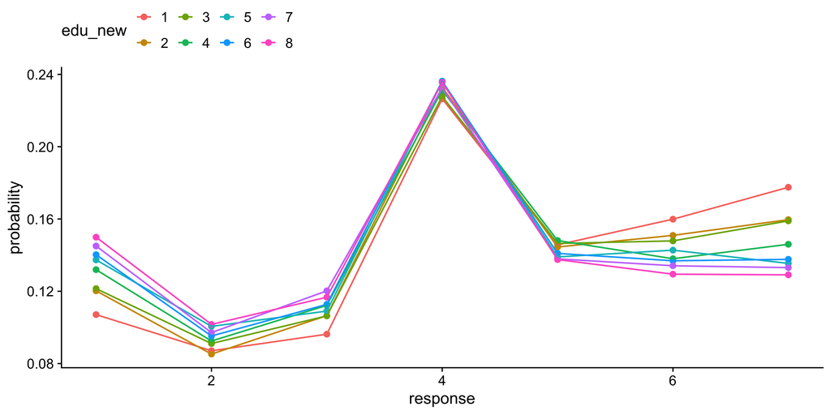

### exercise

Create a new model that includes education as a regular categorical predictor (not monotonic) and compare it to m3. Your tasks:

1. Fit the model using the original `edu` variable (not `edu_new`)
2. Create a plot of the posterior predictive distribution from the new model.

**OPTIONAL** 3. Use create a side-by-side visual comparison of the education effects 4. Interpret whether the monotonic constraint appears to improve the model fit

### solution: fit model

```r
# Fit model with regular categorical education
m3_cat <- brm(
  data = trolley,
  family = cumulative,
  response ~ 1 + action + contact + intention + edu,
  prior = c(prior(normal(0, 1.5), class = Intercept),
            prior(normal(0, 1), class = b)),
  iter = 2000, warmup = 1000, cores = 4, chains = 4,
  file=here("files/models/62.3cat")
)
```

[output not shown]

[output cut: 43 more lines]

[output not shown]

```r
m3_cat
```

```
 Family: cumulative
  Links: mu = logit
Formula: response ~ 1 + action + contact + intention + edu
   Data: trolley (Number of observations: 9930)
  Draws: 4 chains, each with iter = 2000; warmup = 1000; thin = 1;
         total post-warmup draws = 4000

Regression Coefficients:
                      Estimate Est.Error l-95% CI u-95% CI Rhat Bulk_ESS
Intercept[1]             -2.96      0.05    -3.07    -2.85 1.00     3436
Intercept[2]             -2.28      0.05    -2.38    -2.18 1.00     3638
Intercept[3]             -1.69      0.05    -1.78    -1.60 1.00     3583
Intercept[4]             -0.66      0.04    -0.75    -0.57 1.00     3564
Intercept[5]              0.01      0.04    -0.07     0.10 1.00     3793
Intercept[6]              0.92      0.05     0.84     1.02 1.00     4231
action                   -0.71      0.04    -0.79    -0.63 1.00     4402
contact                  -0.96      0.05    -1.07    -0.86 1.00     4222
intention                -0.72      0.04    -0.79    -0.65 1.00     4612
eduElementarySchool       0.91      0.21     0.49     1.32 1.00     5553
eduGraduateDegree        -0.17      0.06    -0.30    -0.05 1.00     4294
eduHighSchoolGraduate    -0.06      0.07    -0.19     0.07 1.00     4695
eduMastersDegree         -0.11      0.06    -0.22    -0.00 1.00     4618
eduMiddleSchool          -0.25      0.15    -0.53     0.03 1.00     5484
eduSomeCollege           -0.31      0.05    -0.40    -0.22 1.00     4405
eduSomeHighSchool         0.13      0.09    -0.05     0.31 1.00     4794
                      Tail_ESS
Intercept[1]              3267
Intercept[2]              3270
Intercept[3]              3552
Intercept[4]              3421
Intercept[5]              3509
Intercept[6]              3473
action                    2860
contact                   3397
intention                 3296
eduElementarySchool       3295
eduGraduateDegree         3086
eduHighSchoolGraduate     3092
eduMastersDegree          3346
eduMiddleSchool           3002
eduSomeCollege            3046
eduSomeHighSchool         2997

Further Distributional Parameters:
     Estimate Est.Error l-95% CI u-95% CI Rhat Bulk_ESS Tail_ESS
disc     1.00      0.00     1.00     1.00   NA       NA       NA

Draws were sampled using sample(hmc). For each parameter, Bulk_ESS
and Tail_ESS are effective sample size measures, and Rhat is the potential
scale reduction factor on split chains (at convergence, Rhat = 1).
```

### solution: ppd

```r
nd <- distinct(
  trolley,
  action, contact, intention, edu
)
predicted_draws(m3_cat, nd) %>%
  ungroup() %>%
  count(edu, .prediction) %>%
  mutate(
    edu = factor(edu,
                 levels = c(
                  "Elementary School",
                  "Middle School",
                  "Some High School",
                  "High School Graduate",
                  "Some College" ,
                  "Bachelor's Degree",
                  "Master's Degree",
                  "Graduate Degree"))) %>%
  with_groups(edu, mutate, total=sum(n)) %>%
  mutate(pk = n/total,
         .prediction = as.numeric(.prediction),
         edu_new = as.factor(edu)) %>%
  ggplot(aes(x = .prediction,  y = pk, color = edu)) +
  geom_point() +
  geom_line() +
  labs( x="response",
        y="probability" ) +
  theme(legend.position = "top")
```

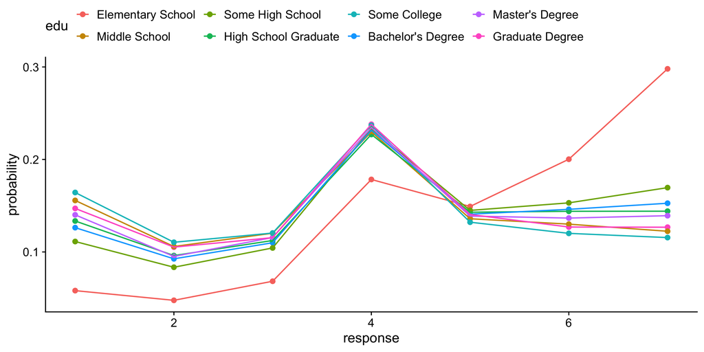

### solution: side-by-side

```r
p1 <- predicted_draws(m3, newdata = distinct(trolley, action, contact, intention, edu_new)) %>%
  mutate(model = "ordered",
         edu = factor(edu_new,
                      levels = c(1:8),
                      labels = c(
                  "Elementary School",
                  "Middle School",
                  "Some High School",
                  "High School Graduate",
                  "Some College" ,
                  "Bachelor's Degree",
                  "Master's Degree",
                  "Graduate Degree")))
p2 <- predicted_draws(m3_cat, newdata = distinct(trolley, action, contact, intention, edu)) %>%
  mutate(model = "categorical")

full_join(p1, p2) %>%
  ungroup() %>%
  count(model, edu, .prediction) %>%
  with_groups(c(model,edu), mutate, total = sum(n)) %>%
  mutate(pk = n/total,
         .prediction = as.numeric(.prediction)) %>%
  ggplot(aes(x = .prediction, y = pk, color = edu)) +
  geom_point(aes(shape = model)) +
  geom_line(aes(linetype = model)) +
  labs(x = "response", y = "probability") +
  guides(color = "none") +
  facet_wrap(~edu) +
  theme(legend.position = "top")
```

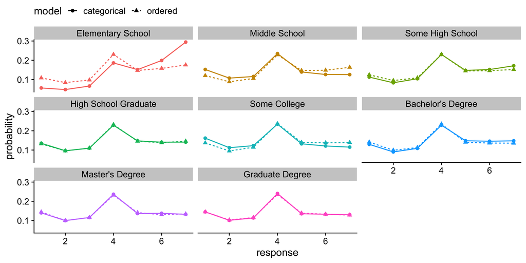

### solution: compare fit

```r
m3  <- add_criterion(m3,        "loo")
m3_cat <- add_criterion(m3_cat, "loo")

loo_compare(m3, m3_cat, criterion = "loo") %>%
  print(simplify = F)
```

```
  model elpd_diff se_diff p_worse diag_diff diag_elpd elpd_loo se_elpd_loo
 m3_cat       0.0     0.0      NA                     -18510.7        38.9
     m3     -30.0     7.6    1.00                     -18540.7        38.1
 p_loo se_p_loo   looic se_looic
  15.5      0.2 37021.4     77.7
  11.1      0.1 37081.3     76.2
```

```r
m3  <- add_criterion(m3,        "waic")
m3_cat <- add_criterion(m3_cat, "waic")

loo_compare(m3, m3_cat, criterion = "waic") %>%
  print(simplify = F)
```

```
  model elpd_diff se_diff p_worse diag_diff diag_elpd elpd_waic se_elpd_waic
 m3_cat       0.0     0.0      NA                      -18510.7         38.9
     m3     -30.0     7.6    1.00                      -18540.7         38.1
 p_waic se_p_waic    waic se_waic
   15.4       0.2 37021.4    77.7
   11.1       0.1 37081.3    76.2
```